# Statistical Hypothesis testing

## Statistical Hypothesis Testing

### Null and Alternative Hypotheses

**Null Hypothesis (H0)**: The statement being tested, usually a statement of no effect or no difference.

**Alternative Hypothesis (H1)**: The statement we want to test against the null hypothesis, indicating the presence of an effect or difference.

**Example:** Let’s consider we want to compare the marathon times of men and women.

- H0: The mean marathon time for men is equal to the mean marathon time for women.
- H1: The mean marathon time for men is different from the mean marathon time for women.

### Types of Errors

**Type I Error (α)**: Rejecting the null hypothesis when it is true. The significance level (alpha) is the probability of making a Type I error.

**Type II Error (β)**: Failing to reject the null hypothesis when it is false. The power of a test (1-β) is the probability of correctly rejecting the null hypothesis.

### P-value

**Definition**: The p-value is the probability of observing the test results, or something more extreme, assuming the null hypothesis is true.

**Calculation and Interpretation**: A small p-value (typically ≤ 0.05) indicates strong evidence against the null hypothesis, so you reject the null hypothesis. A large p-value (> 0.05) indicates weak evidence against the null hypothesis, so you fail to reject the null hypothesis.

### Test Statistics

**Z-test**: Used for hypothesis testing when the population variance is known and the sample size is large.

**t-test**: Used for hypothesis testing when the population variance is unknown and/or the sample size is small.

**Chi-square test**: Used for hypothesis testing on categorical data to assess how likely it is that an observed distribution is due to chance.

**F-test**: Used to compare two variances and often used in the context of ANOVA.

### Example: Comparing Marathon Times for Men and Women

Let’s use real data to compare marathon times for men and women.

```r
# Load necessary libraries
library(dplyr)
```

```r
library(ggplot2)
library(lubridate)
# Load the dataset
library(readxl)
url <- "http://canales.diariovasco.com/documentos/behobia-sansebastian-2015.xls"
destfile <- "behobia2015.xls"
curl::curl_download(url, destfile)
behobia_data <- read_excel(destfile)

# Inspect the data
head(behobia_data)
```

```
## # A tibble: 6 × 11
##   `POSICION GENERAL` DORSAL NOMBRE       `PRIMER APELLIDO` `SEGUNDO APELLIDO`
##                <dbl>  <dbl> <chr>        <chr>             <chr>
## 1                  1      7 CARLES       CASTILLEJO        SALVADOR
## 2                  2      8 JAUME        LEIVA             BEATO
## 3                  3      1 JOSE CARLOS  HERNANDEZ         CABRERA
## 4                  4      9 CAMILO       SANTIAGO          GIMENEZ
## 5                  5      5 PEDRO        NIMO DEL ORO      <NA>
## 6                  6     10 MANUEL ANGEL PENAS             BLANCO
## # ℹ 6 more variables: POROVINCIA <chr>, LOCALIDAD <chr>, `CODIGO POSTAL` <dbl>,
## #   CATEGORIA <chr>, `puesto categoria` <dbl>, tiempo <chr>
```

```r
# Filter data for men and women
men_times <- behobia_data %>% filter(grepl("M", CATEGORIA)) %>% select(tiempo) %>% as.data.frame
men_times <- lapply(lapply(men_times, hms), period_to_seconds)[[1]]
women_times <- behobia_data %>% filter(grepl("F", CATEGORIA)) %>% select(tiempo) %>% as.data.frame
women_times <- lapply(lapply(women_times, hms), period_to_seconds)[[1]]

# Perform a t-test
t_test_result <- t.test(men_times, women_times)

# Display the t-test result
t_test_result
```

```
##
##  Welch Two Sample t-test
##
## data:  men_times and women_times
## t = -22.912, df = 8174.1, p-value < 2.2e-16
## alternative hypothesis: true difference in means is not equal to 0
## 95 percent confidence interval:
##  -1009.2926  -850.2021
## sample estimates:
## mean of x mean of y
##  6687.825  7617.572
```

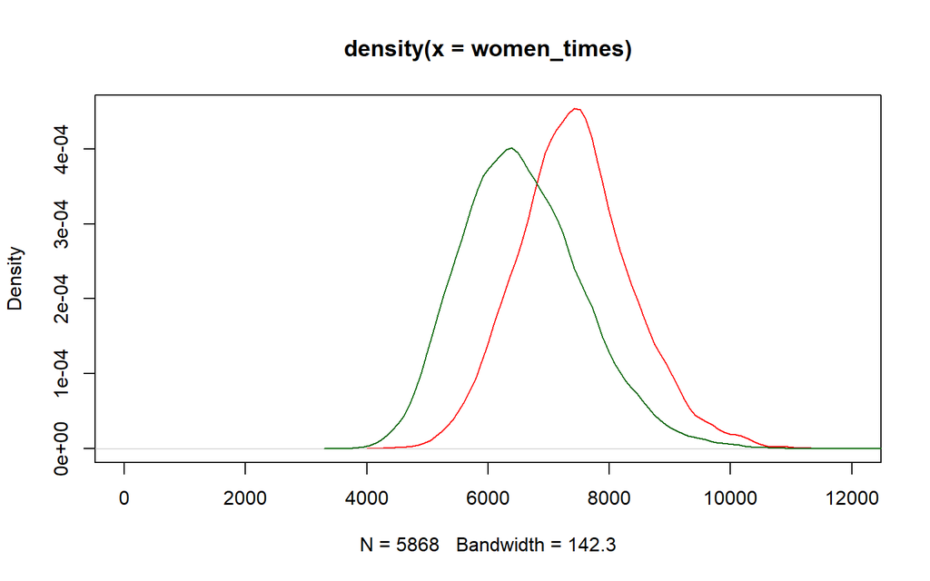

```r
plot(density(women_times), xlim = c(0,12000), col ="red")
lines(density(men_times), xlim = c(0,12000), col = "dark green")
```

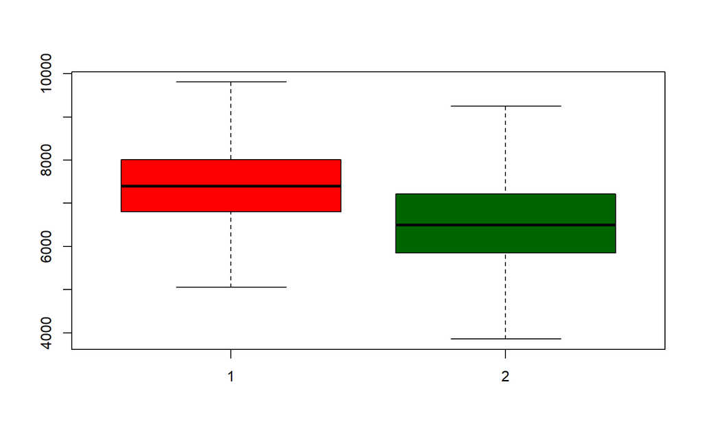

```r
boxplot(women_times, men_times, col= c("red", "dark green"), outline=F)
```

### Interpretation

The results of the t-test provide a p-value and a confidence interval. If the p-value is less than 0.05, we reject the null hypothesis and conclude that there is a significant difference between the marathon times of men and women. Otherwise, we fail to reject the null hypothesis.

### Exercise

Compare the results of the participants whose family name starts with “R” and those that starts with “S”. Is it significant?

```r
# Filter data for men and women
R_times <- behobia_data %>% filter(substr(`PRIMER APELLIDO`, 1, 1) == "R") %>% select(tiempo) %>% as.data.frame
R_times <- lapply(lapply(R_times, hms), period_to_seconds)[[1]]
S_times <- behobia_data %>% filter(substr(`PRIMER APELLIDO`, 1, 1) == "S") %>% select(tiempo) %>% as.data.frame
S_times <- lapply(lapply(S_times, hms), period_to_seconds)[[1]]

# Perform a t-test
t_test_result <- t.test(R_times, S_times)

# Display the t-test result
t_test_result
```

```
##
##  Welch Two Sample t-test
##
## data:  R_times and S_times
## t = 0.68437, df = 3261.1, p-value = 0.4938
## alternative hypothesis: true difference in means is not equal to 0
## 95 percent confidence interval:
##  -113.8699  235.9841
## sample estimates:
## mean of x mean of y
##  6932.022  6870.965
```

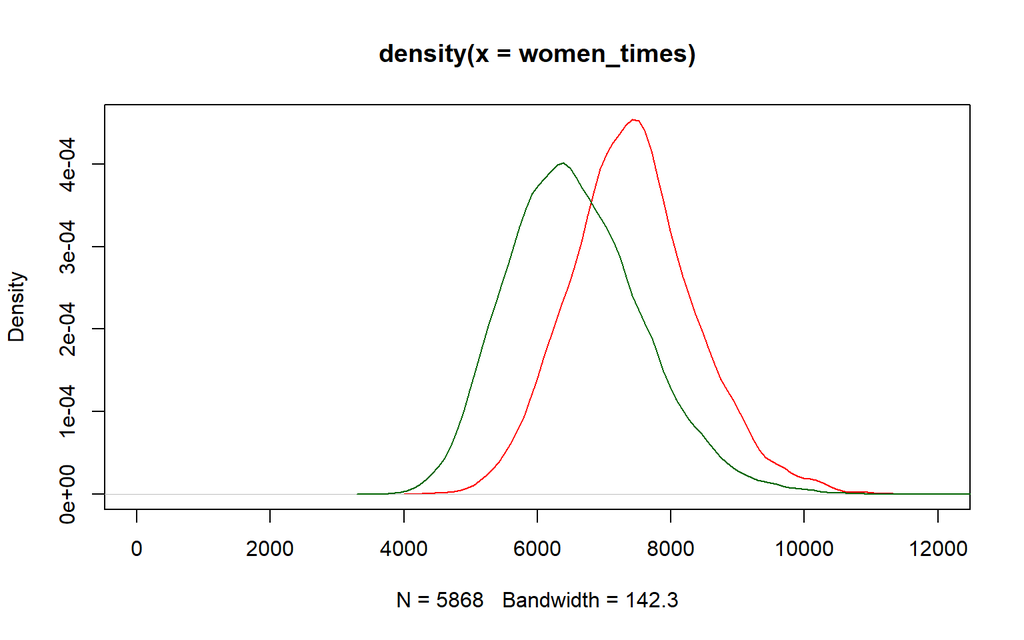

```r
plot(density(women_times), xlim = c(0,12000), col ="red")
lines(density(men_times), xlim = c(0,12000), col = "dark green")
```

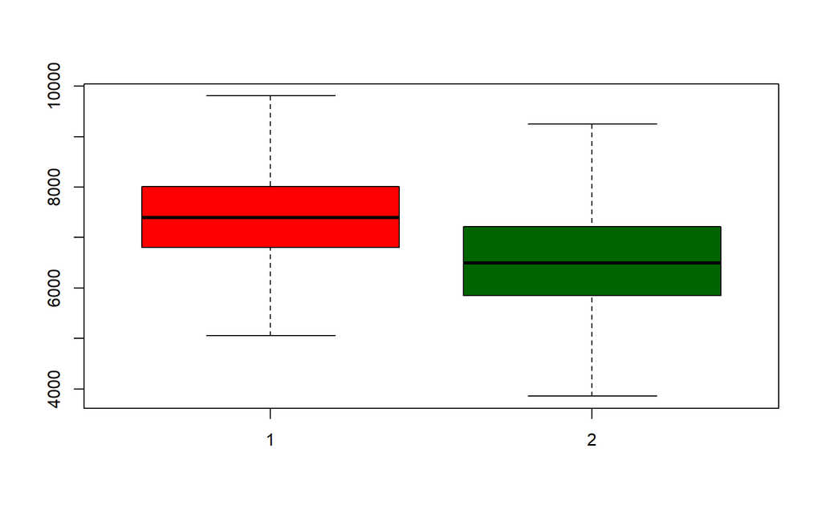

```r
boxplot(women_times, men_times, col= c("red", "dark green"), outline=F)
```

### Conclusion

In this example, we compared the marathon times for men and women using a t-test. Based on the p-value obtained from the test, we made a decision about whether to reject the null hypothesis. This process highlights the importance of hypothesis testing in making data-driven decisions.